# Physical based SCS method

Elad Dente

# Model package objective:

**This functions package objective is to calculate the “intial abstraction” (I) paramter of the SCS method, based on pysical ecoh-hydraulic parameters (rather than the estimation with Curve Number (CN) in the original method.** **The “S”" parameter is still calculated with the CN. the next versions of this package will calculate the S upun the I, after calibration.**

This package include:

1. Atmospheric conductance model
2. canopy conductance model
3. Penamn-Montieth model
4. Interception model
5. SCS method model

**General gross-assumptions:**

1. Evaporation in the interception model is the evapotranspiration of penman-montieth model.
2. Initial abstraction of the SCS is the interception model output (not including other abstraction other then the trees).

## The canopy conductance function, including Jarvis model parameters and LAI

Canopy conductance (Kc; mm/s)= (Jarvis model output (Jarvis_c) * maximum stomatal conuctance (Cleaf_max) * LAI. Shelter factor assumed to be 1. Jarvis_c is function of Rnrad, Rvpd, RT and RTeta. The R in Jarvis parameters is for “relative”. the values can be taken from the plots and equations in “Physical Hydrology: Third Edition” by S. Lawrence Dingman (p. 282). Default values were set the Eilon example (see below). The Kc values can be used in Penman-Montieth model (see below).

The Canopy Conductance Model code:

```r
#' Canopy Conductance Model
#'
#' The R in Jarvis parameters is for "relative". the valus can be taken from the plots in "Physical Hydrology: Third Edition" by S. Lawrence Dingman (p. 282)
#Default values for Quercus ilex (oaks) and Mediterranian sclerophyllous where taken from
#Schulze, E. D., Kelliher, F. M., Korner, C., Lloyd, J., & Leuning, R. (1994). Relationships among maximum stomatal #conductance, ecosystem surface conductance, carbon assimilation rate, and plant nitrogen nutrition: a global ecology #scaling exercise. Annual Review of Ecology and Systematics, 629-660.
#and
#Limousin, J. M., Rambal, S., Ourcival, J. M., & Joffre, R. (2008). Modelling rainfall interception in a Mediterranean #Quercus ilex ecosystem: lesson from a throughfall exclusion experiment. Journal of Hydrology, 357(1), 57-66.



#' @param T (deg c) air temperature at measured height above ground (0>T<40 deg C).
#' @usage calculate canopy conductance, based on the Jarvis model. To be used in Penman-Montieth ET model.
#' @usage will be added
#' @author Elad Dente
#' @return Jarvis model coefficient (Jarvis_c), RT, and canopy conductance (Kc, mm/s)

canopy_conductance<-
  function(Cleaf_max=4.8, Rnrad, Rvpd=0.85,T, Rteta, LAI=1.61) {

    #       Internal Variables
    #       RT  (-) from  T, based on Stewart (1988) relationsip).

    #RT from T
    RT=(T*(40-T)^1.18)/691

    #claculating Jc
    Jarvis_c = (Cleaf_max*Rnrad*Rvpd*RT*Rteta)

    #claculating Kc
    Kc = (Jarvis_c*LAI)

    #return Kc
    return(list(Jarvis_coefficient=Jarvis_c, Temperature_effect=RT, Canopy_conductance_mm.s=Kc))
  }
```

## Example of sensitivity analysis (Kc Vs. T)

```r
#typical T values:
T_i=c(1,5,10,15,20,25,30,35,39);
#Calculating Kc for differnt T_i values:
Kc_res=matrix(,nrow = length(T_i), ncol = 1);
for (i in 1:length(T_i)){
    a<-(canopy_conductance(Rnrad=0.5, T = T_i[i],Rteta=1));
    Kc_res[i,1]=a$Canopy_conductance_mm.s
  }
```

### Kc Vs. T plot

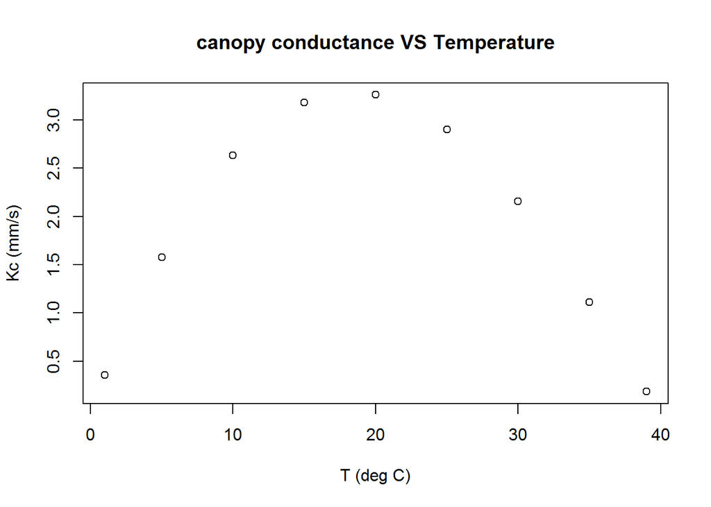

## Atmospheric conductance model

Based on eq.6.48 (p. 278) in “Physical Hydrology: Third Edition” by S. Lawrence Dingman This model gives estimation of the atmospheric conductance (Ca) based on the wind velocity (at 2m above ground, ‘windspeed’) and vegetation height (‘z_veg’)

```r
#' Atmospheric conductance model
#'
#' Based on eq.6.48 (p. 278) in "Physical Hydrology: Third Edition" by S. Lawrence Dingman
#' This model gives estimation of the atmospheric conductance (Ca) based on the
#' wind velocity (at 2m above ground, 'windspeed') and vegetation height ('z_veg')
#'
#' @param   windspeed (cm/s) at 2m above ground
#' @param   z_veg (cm), height of vegetation above ground
#' @usage calculate atmospheric conductance to be used in Penman-Montieth ET model.
#' @author Elad Dente
#' @return zd, z0, zm (all in cm), and atmospheric conductance (cm/s)

atmo_conductance <-
function(windspeed, z_veg) {
    #       Internal Variables
    #
    #       Zd     (cm)    zero-plan displacement height
    #       z0    (cm)     roughness height
    #       zm      (cm)      measurement_height

    #zd from Z_veg
    zd = 0.7*z_veg

    #z0 from z_veg
    z0 = 0.1*z_veg

    #zm from z_veg
    zm = (z_veg +200)

    #claculating Ca
    Ca = (windspeed/(6.25*(log((zm-zd)/z0))^2))

    #return Ca
    return(list(displacement_height=zd, roughness_height=z0, measurement_height=zm, atmospheric_conductance_cm.s=Ca))
  }
```

### Sensitivity analysis

Plot of the Ca (atmospheric conductance) Vs. U (wind speed at 2m above canopy) and Z_veg (vegetation height):

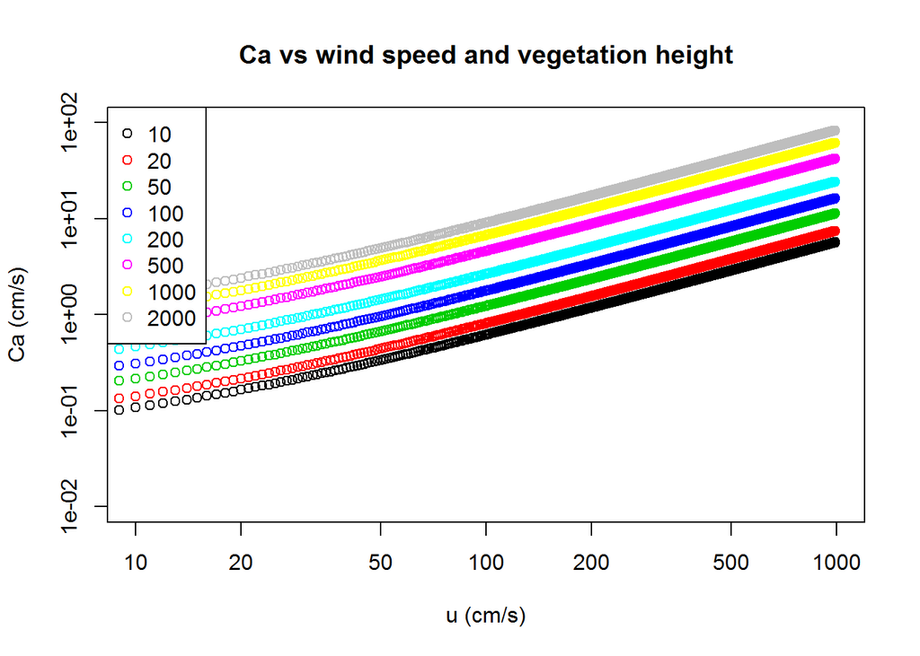

```r
u=seq(10,1000);
z=c(10,20,50,100,200,500,1000,2000);
atmo_res=matrix(,nrow = length(u), ncol = length(z));
for (i in 1:length(u)){
  for (j in 1:length(z)){
    x<-(atmo_conductance(u[i],z[j]));
    atmo_res[i,j]=x$atmospheric_conductance_cm.s
  }
}
matplot(atmo_res, type = c("b"),pch=1,col = 1:8,
        main="Ca vs wind speed and vegetation height", xlab="u (cm/s)", ylab="Ca (cm/s)",
  xlim=c(10, 1000), ylim=c(0.01, 100),log="xy")#plot
legend("topleft", legend = z[1:8], col=1:8, pch=1) #  legend
```

## Penman-montieth model

This model authored by Naomi Tague and edited by me (Elad Dente) It uses the output of the canopy conductance and atmospheric conductance models. Be aware to change units of the atmospheric conductance (cm to mm). day time was set to be 11 hours as default (Israeli winter)

```r
#' Penman Montieth Equation
#'
#' THis function computer evapotranspiration based on radiation, conductance etc
#'

#' @param        Tair    (deg C) air temperature
#' @param    vpd     (Pa)    vapour pressure deficit
#' @param     Rnet    (j/m2/day)      net radiation
#' @param     gs      (mm/s)  surface conductance
#' @param     ga      (mm/s)  aerodynamic conductance
#' @param     CP  =      1010.0 (J/kg*K) specific heat of air
#' @param    Pair = 101325 (Pa)
#' @author Naomi (edited by Elad Dente)
#' @return ET (W/m^2),Evapotranspiration (m/s), Evapotranspiration (mm/day)


penman_montieth =
function(Tair, vpd, Rnet, gs,ga, dayl=11, CP=1010, Pair=101325) {

  #       Internal Variables
  #
  #       rho     (kg/m3)         density of air
  #       CP      (K/jg/degC)     specific heat of air
  #       lhvap   (J/kg)          latent heat of vapourization H20
  #       s       (Pa/degC)       slope of sat vpd vs T curve
  #       rs      (s/m)   surface resistance
  #       ra      (s/m)   aerodynamic resistance


  # convert Rnet to daytime value in j/m2/s
  Rnet = Rnet / (60*60*dayl)

  # convert conductance to resistance and change units
  rs = 1000.0/gs
  ra = 1000.0/ga

  # Assign tk (Kelvins)
  tk = Tair + 273.15

  #       Density of air (rho) as a fn. of air temp.
  rho = 1.292 * ( 0.00428 * Tair )

  #       Latent heat of vapourization as a fn. of Tair.
  lhvap = 2.5023e6 - 2430.54 * Tair

  #       Temperature offsets for slope estimates
  dt = 0.2
  t1 = Tair + dt
  t2 = Tair - dt

  #       Saturation vapour pressures at t1 and t2(Pa)
  pvs1 = 610.7 * exp(17.38 * t1 / ( 239.0 + t1))
  pvs2 = 610.7 * exp(17.38 * t2 / ( 239.0 + t2))

  #       Slope of pvs vs T curve at Tair (Pa/deg C)
  s = ( pvs1 -   pvs2 ) / ( t1 -  t2 )

  #       Calculate gamma
  gamma = CP * Pair / ( lhvap )


  #       Evaporation in W/m2
  et = ((s*Rnet) + (rho*CP*vpd/ra)) / (gamma*(1.0 + rs/ra) +s)


  #       mH20/s = W/m2 * 1kgH20/lhvap J * 1m3H20/1000kGH20
  ewater = ( et/ ( lhvap * 1000 ))

  # mmH20/day
  ewater.day = ewater * dayl*60*60 * 1000

  # return from your function
  return(list(Evapotransiration=et,mH2O.s=ewater,mmH2O.day=ewater.day))
}
```

### Sensitivity analysis:

Test of the sensitivity of the model to temperature, as it changes the Tair and gs (canopy conductance model output) parameters.

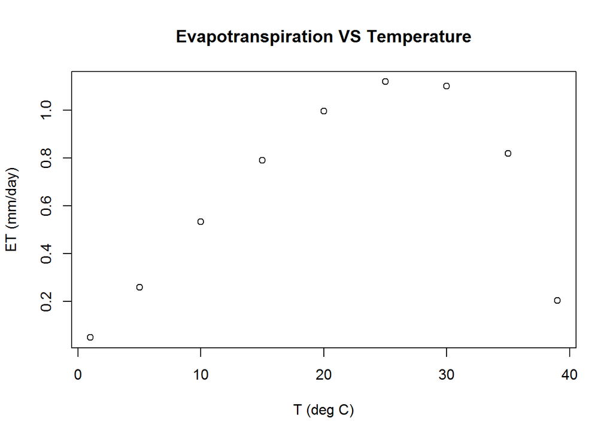

```r
#Calculating ET for differnt T_i values:
ET_res=matrix(,nrow = length(T_i), ncol = 1);
for (i in 1:length(T_i))
  {
    b<-penman_montieth(Tair=T_i[i],vpd=700,Rnet=9000000, gs=Kc_res[i],ga=30)
    ET_res[i,1]=b$mmH2O.day
}
#plot
plot(T_i,ET_res,main="Evapotranspiration VS Temperature", xlab="T (deg C)", ylab="ET (mm/day)")
```

## Interception model

This model calculates the precipitation necessary to fill canopy and stem storage, based on Gash et al. 1995, and Valente et al. 1977. The defaults represent values of Mediterranean Quercus ilex (evergreen oak) ecosystem according to the reference below.

```r
#' Canopy and Stem Interception Model
#'
#' This model calculates the precipitation necessery to fill canopy and stem storage, based on Gash et al. 1995, and Valente et al. 1977.
#' The defults represent values of mediterranean Quercus ilex (evergreen oak) ecosystem acording to the reference below.
#'
#' @usage calculate Interception for a day
#' @param P.rate (mm/hr) is the mean precipitation rate.
#' @param  Evap (mm) total evporation (Here we try to aplly the Penman-montieth ET.)
#' @param P (mm) total precipitation
#' @param c (-) canopy cover per unit area
#' @param S (mm) canopy storage capacity
#' @param St (mm) trunks storage capacity
#' @param Pt (-) the propotion of rain goes to stems
#' @author Elad Dente
#' @return P.canopy (mm) canopy interception, P.stem (mm) stem interception, tot_inter (mm) total interception, and prc.inter (%) precentage of interception in precipitation. .
#' @references Limousin, J. M., Rambal, S., Ourcival, J. M., & Joffre, R. (2008). Modelling rainfall interception in a Mediterranean Quercus ilex ecosystem: lesson from a throughfall exclusion experiment. Journal of Hydrology, 357(1), 57-66.

interception<-
  function(P.rate,Evap,P,c=0.59,S=1.7,St=0.64,Pt=0.1,dayl=11){

  #       Internal Variables
  #       Ec (mm/hr) is the mean evaporation rate.
  #       Sc (mm) canopy storage capcity per cover unit (S/c)
  #       Stc (mm) stem storage capcity per cover unit (St/c)
  #       Ptc (mm) propotion of rain goes to stemss per cover unit (Pt/c)

  #calculating Sc
  Ec= Evap/dayl
  #calculating Sc
  Sc= S/c
  #calculating Stc
  Stc= St/c
  #calculating Ptc
  Ptc= Pt/c

  #calculating P.canopy
  P.canopy=-(P.rate/Ec)*Sc*log(1-(Ec/P.rate))

  #calculating P.stem
  P.stem=(P.rate/(P.rate-Ec))*(Stc/Ptc)

  #total interception
  tot_inter=P.canopy+P.stem

  # % total interception from precipitation
  prc.inter=100*tot_inter/P

  return (list(canopy_interception=P.canopy,stem_interception=P.stem,total_interception=tot_inter,inter.precentage=prc.inter))
}
```

### Sensitivity analysis:

Test of the influence of evapotranspiration.

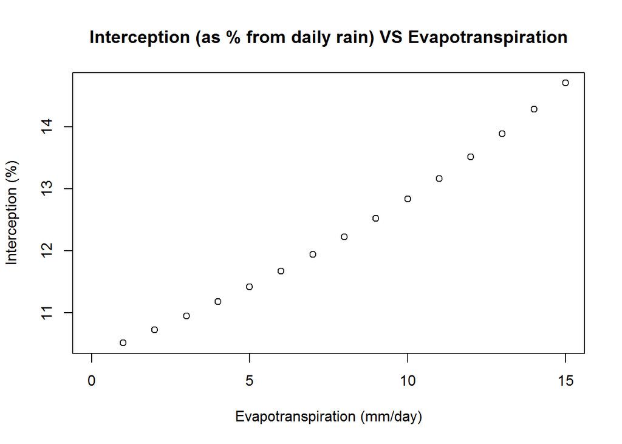

```r
#Calculating total interception for differnt rain intensity values:
Evap_i=seq(0,15)
interception_res=matrix(,nrow = length(Evap_i), ncol = 2);
for (i in 1:length(Evap_i))
  {
    d<-interception(P.rate=4,Evap=Evap_i[i],P=90,c=0.59,S=1.7,St=0.64,Pt=0.1,dayl=11)
    interception_res[i,1]=d$inter.precentage
    interception_res[i,2]=d$total_interception
}
#plot
plot(Evap_i,interception_res[,1],main="Interception (as % from daily rain) VS Evapotranspiration", xlab="Evapotranspiration (mm/day)", ylab="Interception (%)")
```

The Stems storing a lot of water!!!

## SCS method

This function calculate the SCS method for Runoff, in atempt to use physical parameters rather the curve number of the original method. Here the usage is for estimation of daily runoff.

```r
#' SCS Model
#'
#' This function calculate the SCS method for Runoff, in atempt to use physical parameters rather the curve number of #' the original method.
#' Here the usage is for estimation of daily runoff
#'
#'@param P (mm) daily rain.
#'@param I (mm) daily initial abstraction (we try to use the daily interception from the interception model)
#'@param S (-)  (from the CN number. default is 130 for CN 66)
#'@author Elad Dente
#'@references http://www.professorpatel.com/uploads/7/6/5/6/7656897/tr55.pdf
#'@return Q (mm) runoff

SCS=function(P,I,S=130){
  Q=((P-I)^2)/(P-I+S)

  #IS is the I acordin to I=0.2*S
  IS=0.2*S

  return(list(IS=IS,I=I,runoff=Q))
}
```

### Sensitivity analysis:

Test of the influence of Initial abstracts (interception model output).

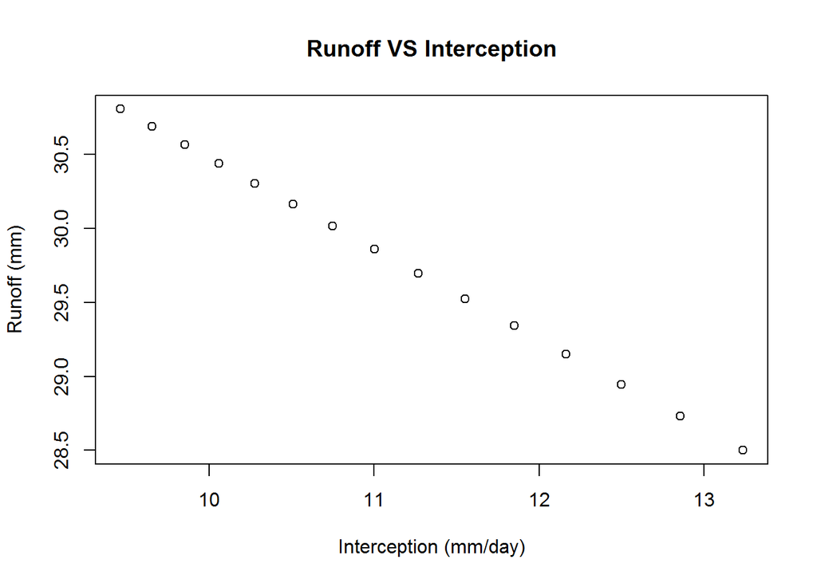

```r
#Calculating total interception for differnt rain intensity values:

SCS_res=matrix(,nrow = length(Evap_i), ncol = 1);
for (i in 1:length(Evap_i))
  {
    e<-SCS(P=90,I=interception_res[i,2],S=130)
    SCS_res[i,1]=e$runoff
}
#plot
plot(interception_res[,2],SCS_res,main="Runoff VS Interception", xlab="Interception (mm/day)", ylab="Runoff (mm)")
```

The intercepitatio influenced the runoff, but in small range…

# Example from Kibutz Eilon Area (North-West Israel)

The example Below is 3 days (11-13/02/2015) of rain in winter 2015. The dataset file is “Eilon_dataset.csv”:

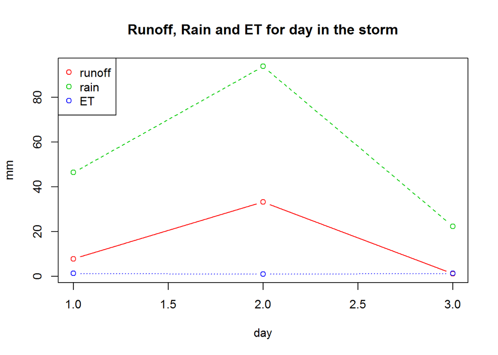

```r
Eilon = read.csv("Datasets/Eilon_dataset.csv", sep=",", header=T)
#model_res=matrix(NA,nrow = 3, ncol = 5, dimnames=list("atmo","canopy","ET","interception","SCS"))

#I know it is not in the smartest way.. I was confused with the metrix command and didn't have time. sorry..
#day1
atmo.day1=atmo_conductance(Eilon$windspeed.m.s.[11],3)
canopy.day1=canopy_conductance(Cleaf_max=4.8, Rnrad=Eilon$Rnrad[11], Rvpd=0.85,T, Rteta=Eilon$Rteta[11], LAI=1.61)
ET.day1=penman_montieth(Tair=Eilon$mean_temp..degc.[11], vpd=Eilon$vpd.Pa.[11], Rnet=Eilon$Nrad.J.m2.day.[11], gs=canopy.day1$Canopy_conductance_mm.s ,ga=10*(atmo.day1$atmospheric_conductance_cm.s), dayl=11, CP=1010, Pair=101325)
inteception.day1=interception(P.rate=Eilon$rain_rate.mm.h.[11],Evap=ET.day1$mmH2O.day,P=Eilon$rain.mm.[11],c=0.59,S=1.7,St=0.64,Pt=0.1,dayl=11)
SCS.day1=SCS(P=Eilon$rain.mm.[11],I=inteception.day1$total_interception,S=130)

#day2
atmo.day2=atmo_conductance(Eilon$windspeed.m.s.[12],3)
canopy.day2=canopy_conductance(Cleaf_max=4.8, Rnrad=Eilon$Rnrad[12], Rvpd=0.85,T, Rteta=Eilon$Rteta[12], LAI=1.61)
ET.day2=penman_montieth(Tair=Eilon$mean_temp..degc.[12], vpd=Eilon$vpd.Pa.[12], Rnet=Eilon$Nrad.J.m2.day.[12], gs=canopy.day2$Canopy_conductance_mm.s ,ga=10*(atmo.day2$atmospheric_conductance_cm.s), dayl=11, CP=1010, Pair=101325)
inteception.day2=interception(P.rate=Eilon$rain_rate.mm.h.[12],Evap=ET.day2$mmH2O.day,P=Eilon$rain.mm.[12],c=0.59,S=1.7,St=0.64,Pt=0.1,dayl=11)
SCS.day2=SCS(P=Eilon$rain.mm.[12],I=inteception.day2$total_interception,S=130)

#day3
atmo.day3=atmo_conductance(Eilon$windspeed.m.s.[13],3)
canopy.day3=canopy_conductance(Cleaf_max=4.8, Rnrad=Eilon$Rnrad[13], Rvpd=0.85,T, Rteta=Eilon$Rteta[13], LAI=1.61)
ET.day3=penman_montieth(Tair=Eilon$mean_temp..degc.[13], vpd=Eilon$vpd.Pa.[13], Rnet=Eilon$Nrad.J.m2.day.[13], gs=canopy.day3$Canopy_conductance_mm.s ,ga=10*(atmo.day3$atmospheric_conductance_cm.s), dayl=11, CP=1010, Pair=101325)
inteception.day3=interception(P.rate=Eilon$rain_rate.mm.h.[13],Evap=ET.day3$mmH2O.day,P=Eilon$rain.mm.[13],c=0.59,S=1.7,St=0.64,Pt=0.1,dayl=11)
SCS.day3=SCS(P=Eilon$rain.mm.[13],I=inteception.day3$total_interception,S=130)

model.res=matrix(,nrow=3,ncol=5)
model.res[1,1]=Eilon$Date[11]
model.res[2,1]=Eilon$Date[12]
model.res[3,1]=Eilon$Date[13]
model.res[1,2]=SCS.day1$runoff
model.res[2,2]=SCS.day2$runoff
model.res[3,2]=SCS.day3$runoff
model.res[1,3]=Eilon$rain.mm.[11]
model.res[2,3]=Eilon$rain.mm.[12]
model.res[3,3]=Eilon$rain.mm.[13]
model.res[1,4]=ET.day1$mmH2O.day
model.res[2,4]=ET.day2$mmH2O.day
model.res[3,4]=ET.day3$mmH2O.day
#plot (model.res[,1],model.res[,c(2,3],main="Runoff in Eilon, 11-13/02/2015", xlab="day", ylab="Runoff (mm)", #type="b")
matplot(model.res[,2:4], type = c("b"),pch=1,col = 2:4,
main="Runoff, Rain and ET for day in the storm", xlab="day", ylab="mm")#plot
legend("topleft", legend = c("runoff","rain", "ET"), col=2:4, pch=1) #  legend
```

## More anlaysis and nicer plots in next versions of this package!